# CS6140 Assignment 4

Chengbo Gu

```r
set.seed(123)
Rawdata <- read.table("SouthAfricanHeartDisease.txt", sep=",",
                     stringsAsFactors = FALSE, header = TRUE)
#Rawdata[,11] <- as.factor(Rawdata[,11])
Mydata <- Rawdata[,-6]
Mydata <- Mydata[,-1]


predictors <- Mydata[,1:8]
means <- apply(predictors, 2, mean)
sds <- apply(predictors, 2, sd)

predictors <- t(apply(predictors, 1, function(x) (x-means)/sds))
response <- Mydata[,9]

train <- sample(x=1:nrow(Mydata), size=nrow(Mydata)/2)
trainResponse <- response[train]
testResponse <- response[-train]

trainPredictors <- predictors[train,]
testPredictors <- predictors[-train,]

trainSet <- Mydata[train,]
testSet <- Mydata[-train,]
```

### problem 3. Naive Bayes classifier

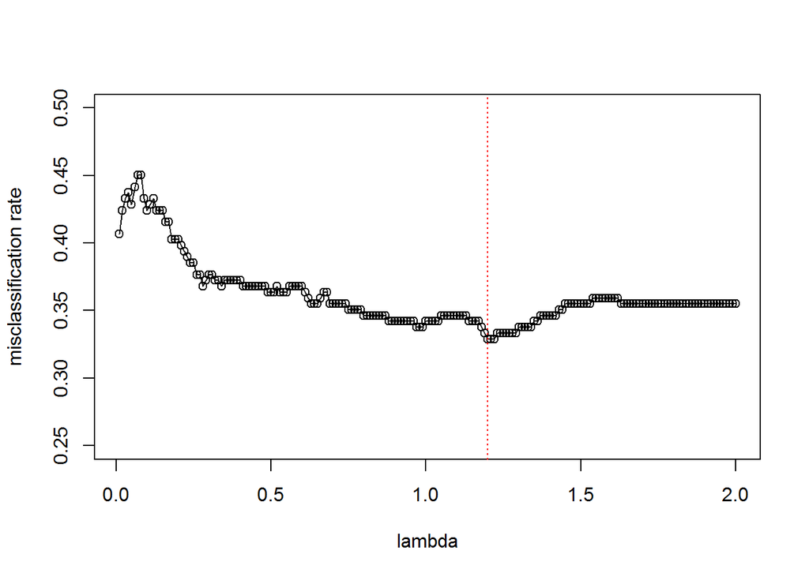

```
## Best lambda is : 1.2
```

```r
# leave-one-out cross validation
# only support response contains 0 and 1
naive.bayes.cv <- function(lambda.seq, predictors, response){
  miscl <- rep(NA, length(lambda.seq))
  for (k in 1:length(lambda.seq)) {
    lambda <- lambda.seq[k]
    n <- length(response)
    naiveBayes.raw <- rep(NA, n)
    for (i in 1:n) {
      data.tr.predictors <- predictors[-i,]
      data.tr.response <- response[-i]
      data.test.predictors <- predictors[i,]
      data.test.response <- response[i]
      density <- dnorm(abs(data.test.predictors - data.tr.predictors)/lambda, mean = 0, sd=1)
      #print(density)
      ones <- which(data.tr.response %in% c(1))
      response.ones <- which(response %in% c(1))

      len.ones <- length(response.ones)
      len.zeros <- n - len.ones
      prior.ones <- len.ones/n
      prior.zeros <- len.zeros/n

      density.ones <- density[ones,]
      density.zeros <- density[-ones,]

      density.one <- prod(apply(density.ones, 2, sum)/len.ones)
      density.zero <- prod(apply(density.zeros, 2, sum)/len.zeros)

      prob.one <- prior.ones * density.one / (prior.ones * density.one + prior.zeros * density.zero)
      naiveBayes.raw[i] <- prob.one
    }
    cl <- sapply(naiveBayes.raw, function(x) x>0.5)
    miscl[k] <- 1-mean(cl == response)
  }
  plot(lambda.seq, miscl, ylim=c(0.25,0.5), ylab="misclassification rate", xlab="lambda")
  lines(lambda.seq, miscl, ylim=c(0.25,0.5))
  abline(v=lambda.seq[which.min(miscl)], col="red", lty=3)
  cat("Best lambda is :", lambda.seq[which.min(miscl)])
}

lambda.seq <- seq(0.01, 2, 0.01)
naive.bayes.cv(lambda.seq, trainPredictors, trainResponse)
```

```r
# using train dataset
naive.bayes.cl <- function(lambda, predictors, response, trainPredictors) {
  n <- length(response)
  naiveBayes.raw <- rep(NA, n)
  for (i in 1:n) {

    data.test.predictors <- predictors[i,]
    density <- dnorm(abs(data.test.predictors - trainPredictors)/lambda, mean = 0, sd=1)

    ones <- which(trainResponse %in% c(1))
    response.ones <- which(trainResponse %in% c(1))

    len.ones <- length(response.ones)
    len.zeros <- length(trainResponse) - len.ones
    prior.ones <- len.ones/length(trainResponse)
    prior.zeros <- len.zeros/length(trainResponse)

    density.ones <- density[ones,]
    density.zeros <- density[-ones,]

    density.one <- prod(apply(density.ones, 2, sum)/len.ones)
    density.zero <- prod(apply(density.zeros, 2, sum)/len.zeros)

    prob.one <- prior.ones * density.one / (prior.ones * density.one + prior.zeros * density.zero)
    naiveBayes.raw[i] <- prob.one
  }
  return(naiveBayes.raw)
}
naiveBayes.scores <- naive.bayes.cl(1.2, testPredictors, testResponse, trainPredictors)
```

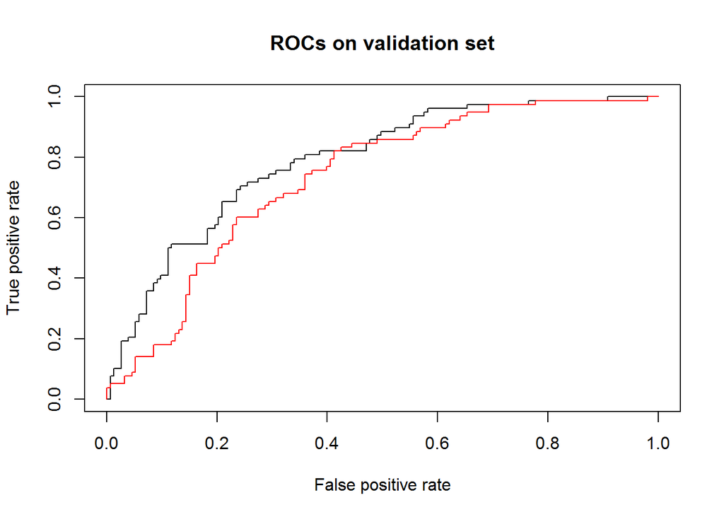

```r
lda.fit <- lda(x=as.matrix(trainSet[,-9]), grouping= as.factor(trainSet[,9]), cv=TRUE)

# lda
# prediction on the validation set
pred.lda.test <- predict(lda.fit, newx=testSet[,-9])

# ROC on the validation set
scores <- predict(lda.fit, newdata= testSet[,-9])$posterior[,2]
pred <- prediction( scores, labels= testSet$chd )
perf <- performance(pred, "tpr", "fpr")
plot(perf, col= 1, main="ROCs on validation set")
# print out the area under the curve
lda.test <- unlist(attributes(performance(pred, "auc"))$y.values)

# naive bayes
pred <- prediction(naiveBayes.scores, labels=testResponse)
perf <- performance(pred, "tpr", "fpr")

# plot the ROC curve
plot(perf, col= 2, add=T)
```

```r
# print out the area under the curve
naive.test <- unlist(attributes(performance(pred, "auc"))$y.values)
```

### problem 4. Tree-based Methods

##### (a) JWHT Chapter 8, Problem 9, but using the “South African Heart Disease” dataset

###### (a-b)

```r
tree.cl <- tree(as.factor(chd) ~ ., data=trainSet)
summary(tree.cl)
```

```
##
## Classification tree:
## tree(formula = as.factor(chd) ~ ., data = trainSet)
## Number of terminal nodes:  23
## Residual mean deviance:  0.5971 = 124.2 / 208
## Misclassification error rate: 0.1472 = 34 / 231
```

Training error rate is 14.72%. There are 23 terminal nodes.

###### (c)

```r
tree.cl
```

```
## node), split, n, deviance, yval, (yprob)
##       * denotes terminal node
##
##   1) root 231 300.500 0 ( 0.64502 0.35498 )
##     2) tobacco < 0.22 67  40.400 0 ( 0.91045 0.08955 )
##       4) sbp < 141 49   0.000 0 ( 1.00000 0.00000 ) *
##       5) sbp > 141 18  22.910 0 ( 0.66667 0.33333 )
##        10) obesity < 29.41 12  16.640 0 ( 0.50000 0.50000 )
##          20) adiposity < 19.91 5   5.004 0 ( 0.80000 0.20000 ) *
##          21) adiposity > 19.91 7   8.376 1 ( 0.28571 0.71429 ) *
##        11) obesity > 29.41 6   0.000 0 ( 1.00000 0.00000 ) *
##     3) tobacco > 0.22 164 226.500 0 ( 0.53659 0.46341 )
##       6) age < 50.5 90 115.900 0 ( 0.65556 0.34444 )
##        12) typea < 53.5 41  40.470 0 ( 0.80488 0.19512 )
##          24) ldl < 6.445 34  24.630 0 ( 0.88235 0.11765 )
##            48) obesity < 25.265 18  19.070 0 ( 0.77778 0.22222 )
##              96) adiposity < 18.96 8   0.000 0 ( 1.00000 0.00000 ) *
##              97) adiposity > 18.96 10  13.460 0 ( 0.60000 0.40000 ) *
##            49) obesity > 25.265 16   0.000 0 ( 1.00000 0.00000 ) *
##          25) ldl > 6.445 7   9.561 1 ( 0.42857 0.57143 ) *
##        13) typea > 53.5 49  67.740 0 ( 0.53061 0.46939 )
##          26) sbp < 113 5   0.000 1 ( 0.00000 1.00000 ) *
##          27) sbp > 113 44  59.530 0 ( 0.59091 0.40909 )
##            54) adiposity < 20.345 12  15.280 1 ( 0.33333 0.66667 )
##             108) adiposity < 15.77 6   7.638 0 ( 0.66667 0.33333 ) *
##             109) adiposity > 15.77 6   0.000 1 ( 0.00000 1.00000 ) *
##            55) adiposity > 20.345 32  39.750 0 ( 0.68750 0.31250 )
##             110) age < 31.5 6   0.000 0 ( 1.00000 0.00000 ) *
##             111) age > 31.5 26  34.650 0 ( 0.61538 0.38462 ) *
##       7) age > 50.5 74  99.100 1 ( 0.39189 0.60811 )
##        14) ldl < 8.205 68  92.790 1 ( 0.42647 0.57353 )
##          28) tobacco < 7.47 48  66.460 0 ( 0.52083 0.47917 )
##            56) tobacco < 4.65 33  44.990 1 ( 0.42424 0.57576 )
##             112) obesity < 27.63 24  33.100 0 ( 0.54167 0.45833 )
##               224) alcohol < 0.37 7   5.742 1 ( 0.14286 0.85714 ) *
##               225) alcohol > 0.37 17  20.600 0 ( 0.70588 0.29412 )
##                 450) sbp < 157 12  16.300 0 ( 0.58333 0.41667 ) *
##                 451) sbp > 157 5   0.000 0 ( 1.00000 0.00000 ) *
##             113) obesity > 27.63 9   6.279 1 ( 0.11111 0.88889 ) *
##            57) tobacco > 4.65 15  17.400 0 ( 0.73333 0.26667 )
##             114) sbp < 155 9   0.000 0 ( 1.00000 0.00000 ) *
##             115) sbp > 155 6   7.638 1 ( 0.33333 0.66667 ) *
##          29) tobacco > 7.47 20  20.020 1 ( 0.20000 0.80000 )
##            58) tobacco < 10 8   0.000 1 ( 0.00000 1.00000 ) *
##            59) tobacco > 10 12  15.280 1 ( 0.33333 0.66667 )
##             118) age < 56 5   0.000 1 ( 0.00000 1.00000 ) *
##             119) age > 56 7   9.561 0 ( 0.57143 0.42857 ) *
##        15) ldl > 8.205 6   0.000 1 ( 0.00000 1.00000 ) *
```

15. ldl > 8.205 6 0.000 1 ( 0.00000 1.00000 ) To go to the 15th terminal node, ldl should be greater than 8.205, there are 6 observations in this branch, the deviance is 0, the prediction is chd = 1 with probability 1.

###### (d)

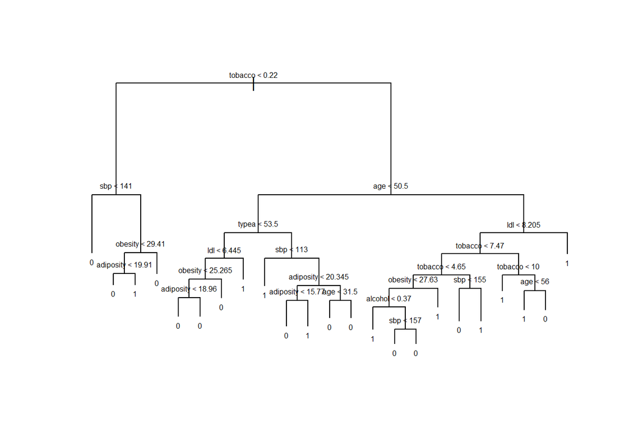

```r
plot(tree.cl)
text(tree.cl ,pretty =0, cex=0.5)
```

Initial tree built for training set without pruning.

###### (e)

```r
tree.pred <- predict (tree.cl , testSet, type ="class")
table(tree.pred, testSet[,9])
```

```
##
## tree.pred   0   1
##         0 114  50
##         1  39  28
```

The misclassification rate for testing set is 38.53%.

###### (f-i)

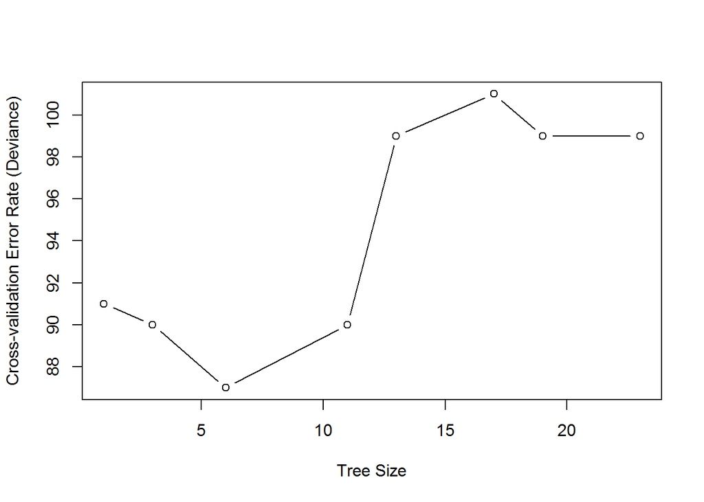

```r
set.seed(531)
cv.tree.cl =cv.tree(tree.cl , FUN=prune.misclass)
plot(cv.tree.cl$size ,cv.tree.cl$dev ,type="b", ylab="Cross-validation Error Rate (Deviance)", xlab="Tree Size")
```

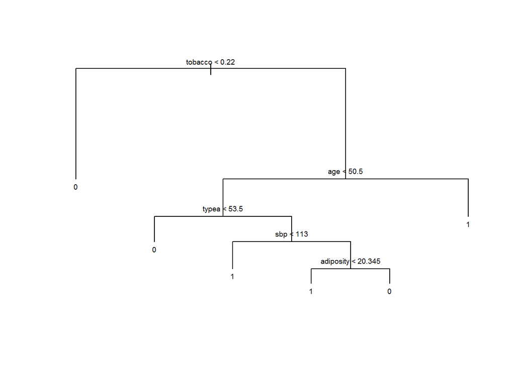

```r
prune.tree =prune.misclass (tree.cl ,best =6)
plot(prune.tree)
text(prune.tree ,pretty =0, cex=0.6)
```

###### (j)

```r
tree.prune.train.pred <- predict(prune.tree, trainSet, type="class")
mean(tree.prune.train.pred != trainSet[,9])
```

```
## [1] 0.2467532
```

```r
prune.train.acc <- 1-mean(tree.prune.train.pred != trainSet[,9])
```

The misclassification error on training set of pruned tree is 24.68% which is higher than the one (14.72%) of unpruned tree.

###### (k)

```r
tree.prune.test.pred <- predict (prune.tree , testSet, type="class")
mean(tree.prune.test.pred != testSet[,9])
```

```
## [1] 0.3419913
```

```r
prune.test.acc <- 1-mean(tree.prune.test.pred != testSet[,9])
```

The misclassification error on testing set of pruned tree is 34.20% which is lower than the one (38.53%) of unpruned tree.

##### (b) Perform bagging on the training set, with a range of tree numbers B.

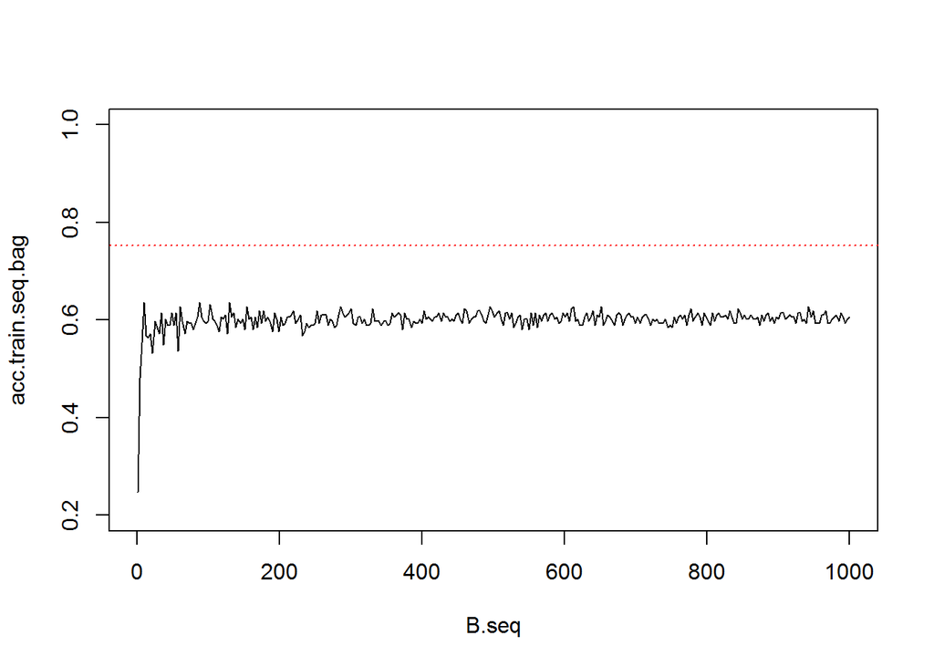

```r
B.seq <- seq(1, 1000, 3)
acc.train.seq.bag <- rep(NA, length(B.seq))
acc.test.seq.bag <- rep(NA, length(B.seq))
set.seed (123)
for (i in 1:length(B.seq)) {
  bagging <- randomForest(as.factor(chd)~.,data=trainSet , mtry=8, importance =TRUE, ntree = B.seq[i])
  acc.train.seq.bag[i] <- (bagging$confusion[1,1] + bagging$confusion[2,2])/dim(trainSet)[1]
  pred.bagging <- predict (bagging ,newdata =testSet)
  acc.test.seq.bag[i] <- mean(pred.bagging == testSet[,9])
}
plot(B.seq, acc.train.seq.bag, ylim=c(0.2,1), type="l")
#lines(B.seq, acc.train.seq, ylim=c(0.2,1))
abline(h=prune.train.acc, col="red", lty=3)
```

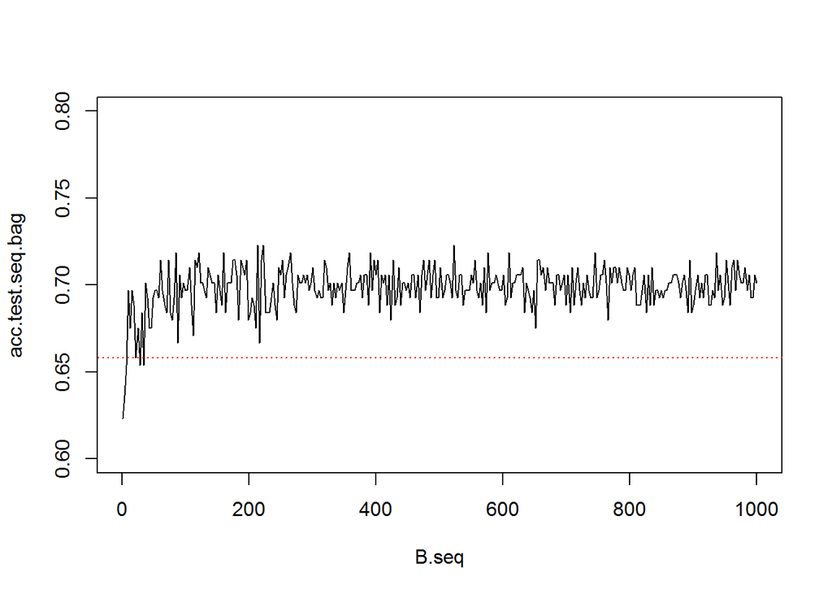

```r
plot(B.seq, acc.test.seq.bag, ylim=c(0.6,0.8), type="l")
#lines(B.seq, acc.test.seq, ylim=c(0.6,0.8))
abline(h=prune.test.acc, col="red", lty=3)
```

```r
#bagging
#(bagging$confusion[1,1] + bagging$confusion[2,2])/dim(trainSet)[1]
```

##### (c) Perform random forest on the training set, with a range of tree numbers B, and with two different numbers of selected predictors m of your choice.

```r
acc.train.seq.sqrt <- rep(NA, length(B.seq))
acc.test.seq.sqrt <- rep(NA, length(B.seq))
acc.train.seq.by2 <- rep(NA, length(B.seq))
acc.test.seq.by2 <- rep(NA, length(B.seq))
set.seed (123)
for (i in 1:length(B.seq)) {

  rf.tree.sqrt <- randomForest(as.factor(chd)~., data=trainSet , mtry=sqrt(8), importance =TRUE, ntree = B.seq[i])
  rf.tree.by2 <- randomForest(as.factor(chd)~., data=trainSet , mtry=sqrt(4), importance =TRUE, ntree = B.seq[i])

  acc.train.seq.sqrt[i] <- (rf.tree.sqrt$confusion[1,1] + rf.tree.sqrt$confusion[2,2])/dim(trainSet)[1]
  pred.rf.sqrt <- predict (rf.tree.sqrt ,newdata =testSet)
  acc.test.seq.sqrt[i] <- mean(pred.rf.sqrt == testSet[,9])

  acc.train.seq.by2[i] <- (rf.tree.by2$confusion[1,1] + rf.tree.by2$confusion[2,2])/dim(trainSet)[1]
  pred.rf.by2 <- predict (rf.tree.by2 ,newdata =testSet)
  acc.test.seq.by2[i] <- mean(pred.rf.by2 == testSet[,9])
}
```

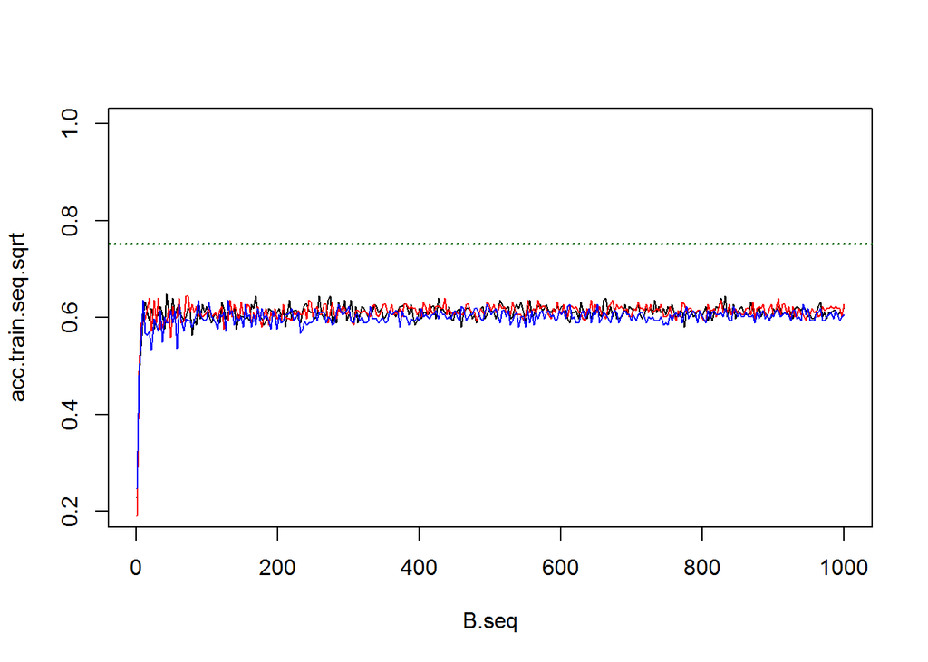

```r
# black: rf with sqrt(p) features
# red: rf with p/2 features
# blue: bagging
# purple: single pruned tree
plot(B.seq, acc.train.seq.sqrt, ylim=c(0.2,1), type="l")
lines(B.seq, acc.train.seq.by2, col="red")
lines(B.seq, acc.train.seq.bag, col="blue")
abline(h=prune.train.acc, col="darkgreen", lty=3)
```

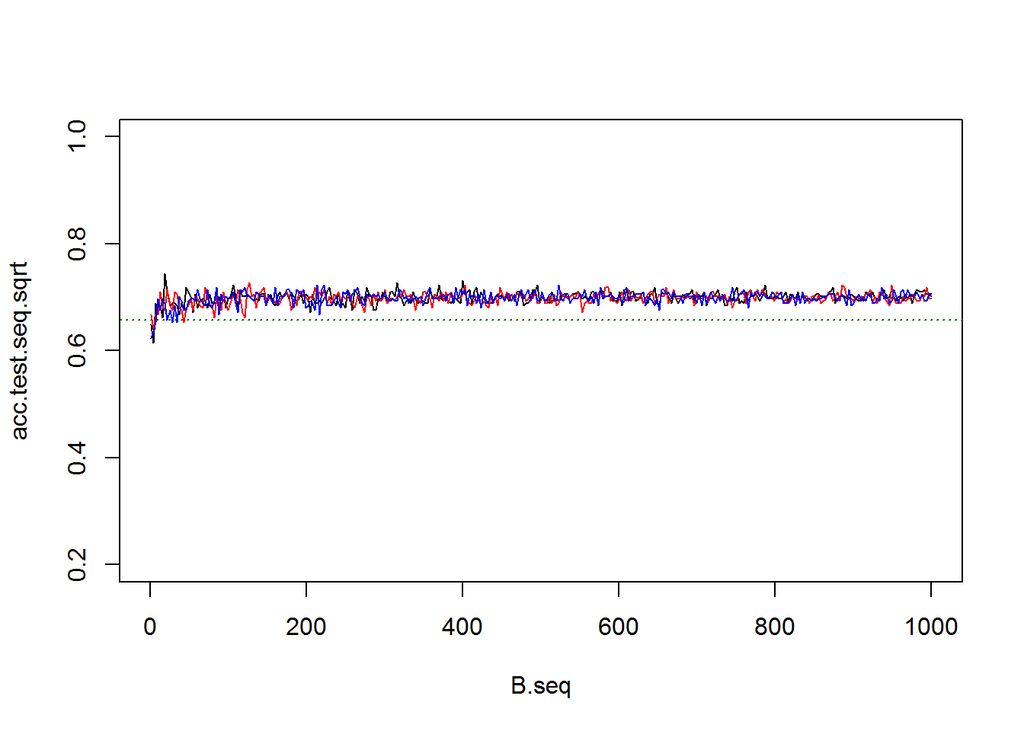

```r
plot(B.seq, acc.test.seq.sqrt, ylim=c(0.2,1), type="l")
lines(B.seq, acc.test.seq.by2, col="red")
lines(B.seq, acc.test.seq.bag, col="blue")
abline(h=prune.test.acc, col="darkgreen", lty=3)
```

##### (d) Perform boosting on the training set with 1,000 trees for a range of values of the shrinkage parameter $\lambda$.

```r
set.seed(123)
grid <- seq(0.01, 5, 0.05)
acc.train.seq.boost <- rep(NA, length(grid))
acc.test.seq.boost <- rep(NA, length(grid))
for (i in 1:length(grid)) {
  boost.tree <- gbm(chd~., data=trainSet, distribution="bernoulli", n.trees =1000, interaction.depth=4, shrinkage=grid[i])
  boost.tree.train.pred <- predict(boost.tree, data=trainSet, n.trees=1000) > 0
  acc.train.seq.boost[i] <- mean(boost.tree.train.pred == trainSet$chd)

  boost.tree.test.pred <- predict(boost.tree, data=testSet, n.trees=1000) > 0
  acc.test.seq.boost[i] <- mean(boost.tree.test.pred == testSet$chd)
}
```

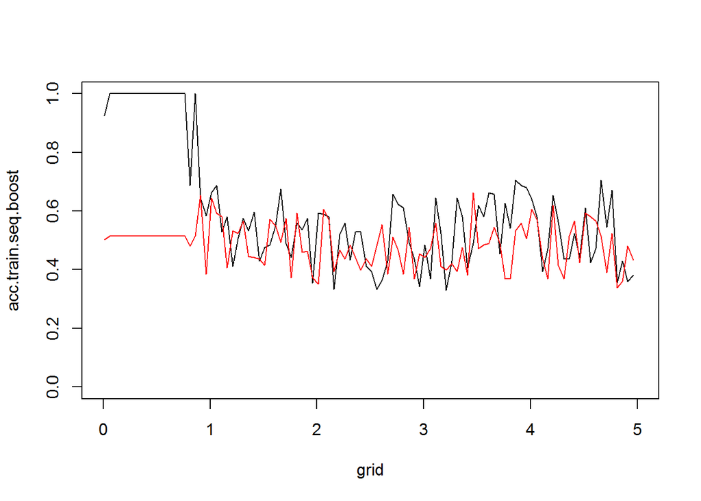

```r
# black: train
# red: test
plot(grid, acc.train.seq.boost, type="l", xlim=c(0,5), ylim=c(0,1))
lines(grid, acc.test.seq.boost, type="l", col="red")
```

```r
# summary(boost.tree)
# how to select lambda?
```

### 5. JWHT Chapter 9, Problem 3.

##### (a)

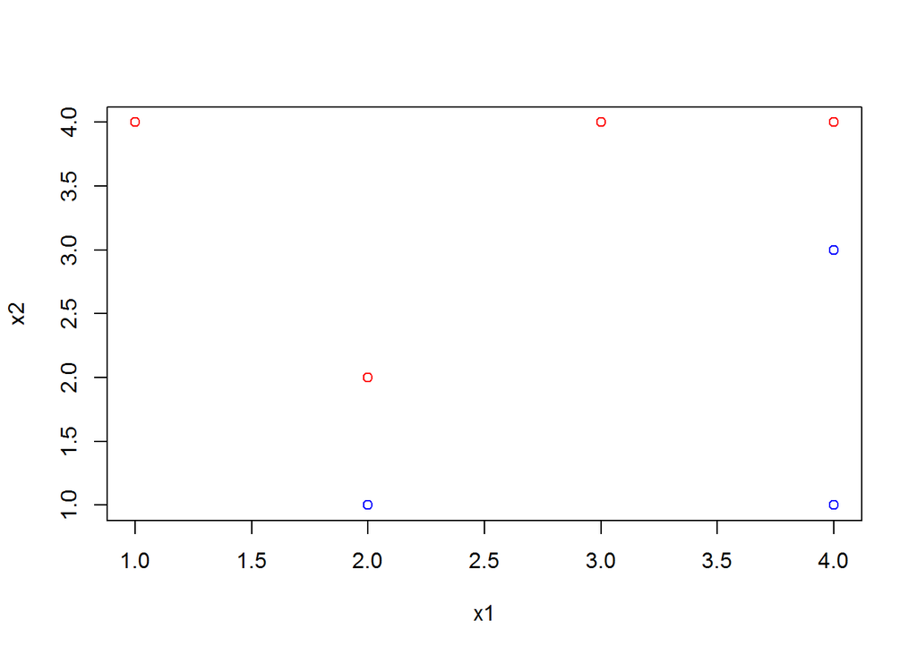

```r
x1 <- c(3,2,4,1,2,4,4)
x2 <- c(4,2,4,4,1,3,1)
y <- c("red", "red","red","red","blue","blue","blue")
plot(x1,x2, col=y)
```

##### (b)

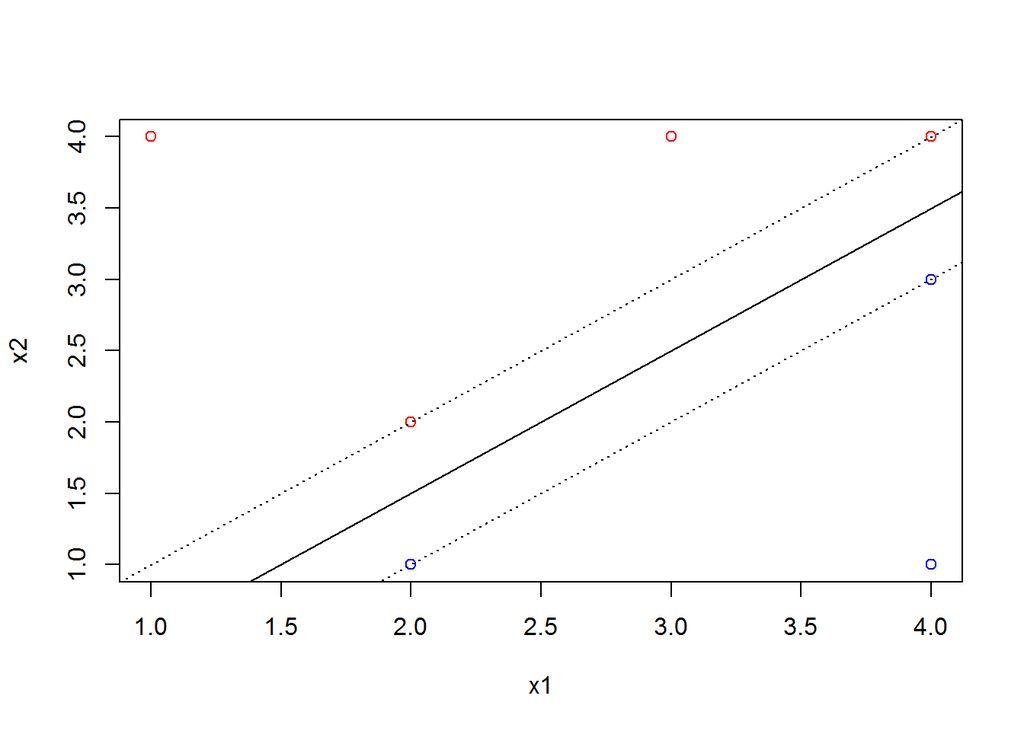

```r
plot(x1,x2, col=y)
abline(a=-0.5, b=1)
abline(a=0, b=1, lty=3)
abline(a=-1, b=1, lty=3)
```

The hyperplane here is :
$$0.5-x_1+x_2=0$$

##### (c)

The classification rule is:

Red if $0.5-x_1+x_2>0$

Blue if $0.5-x_1+x_2<0$

##### (d)

The margin here is the perpendicular distance from one dotted line to the solid line.

And the value of the margin is $\frac{\sqrt{2}}{4}$.

##### (e)

The support vectors are:

(2,1),(2,2),(4,3),(4,4)

##### (f)

For SVM, the points that would affect the hyperplane are the support vectors.

Clearly the seventh point (4,1) is not a support vector and far from the hyperplane.

Thus, a slight movement of the seventh observation would not affect the maximal margin hyperplane.

##### (g)

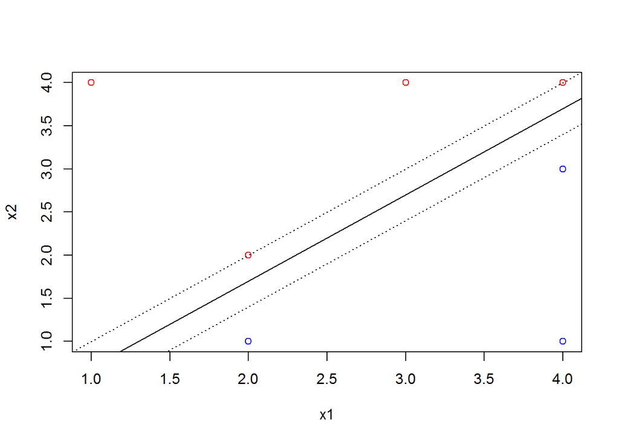

```r
plot(x1,x2, col=y)
abline(a=-0.3, b=1)
abline(a=0, b=1, lty=3)
abline(a=-0.6, b=1, lty=3)
```

There are infinite number of hyperplanes that are not the optimal ones. Here is one with $0.3-x_1+x_2=0$.

##### (h)

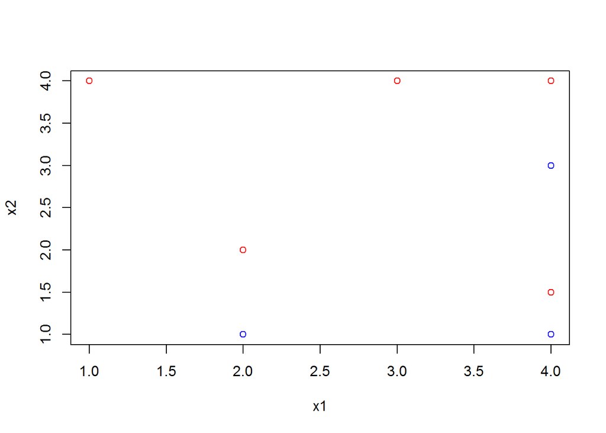

```r
x1 <- c(3,2,4,1,2,4,4,4)
x2 <- c(4,2,4,4,1,3,1,1.5)
y <- c("red", "red","red","red","blue","blue","blue", "red")
plot(x1,x2, col=y)
```

The two classes won’t be linearly separable with an additional red point (4, 1.5).